# Final Project

# ——————————————————————————

# (5)Check confounding – Mean Cardiovascular Disease Prevalence: Poverty by Unemployment rate

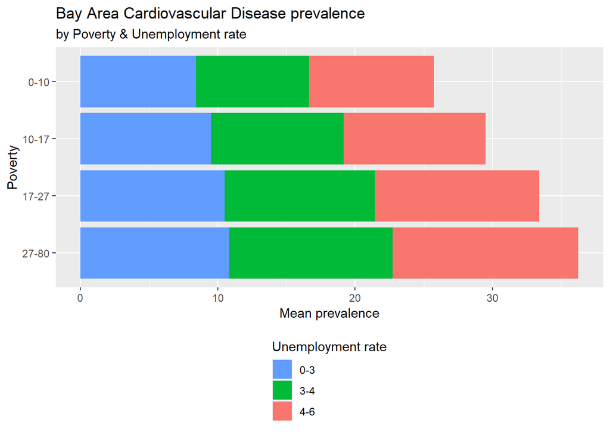

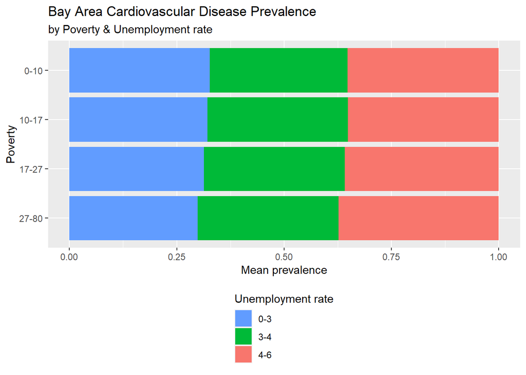

Result: As the Unemployment rate increases, the Mean Cardiovascular Disease Prevalence gets larger. As the Poverty percentage increases, the Mean Cardiovascular Disease Prevalence gets larger, too. For the groups with higher Unemployment rate, the Mean Cardiovascular Disease Prevalence increases as Poverty percentage increases.

# ——————————————————————————

# (6)Check confounding – Mean Cardiovascular Disease Prevalence: Poverty by White

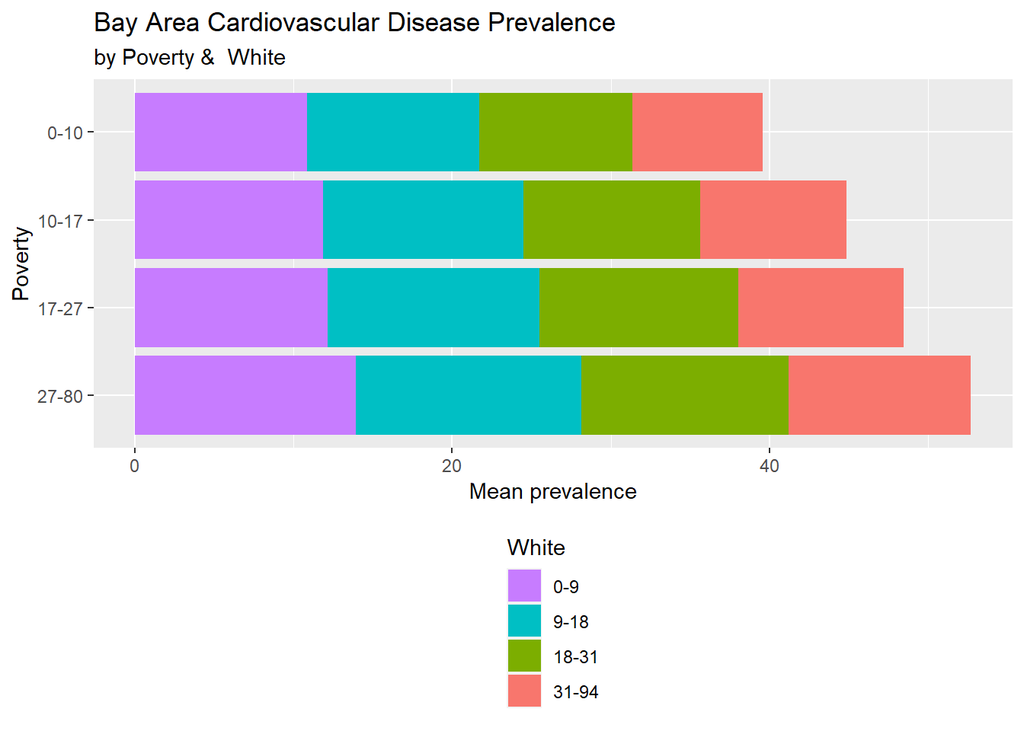

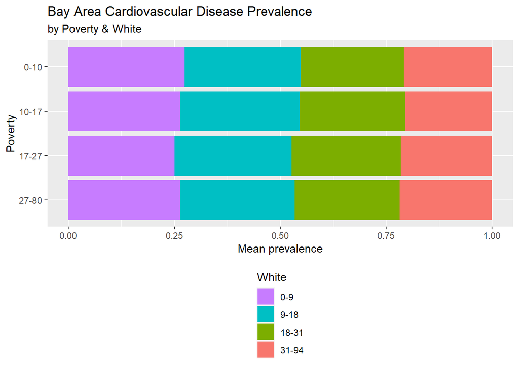

Result: As the White percentage increases, the Mean Cardiovascular Disease Prevalence gets lesser. For the groups with Poverty percentage of 10-17 & 17-27, the Mean Cardiovascular Disease Prevalence slightly decreases as the White percentage increases.

# ——————————————————————————

# (7)Check confounding – Mean Cardiovascular Disease Prevalence: Poverty by African_American

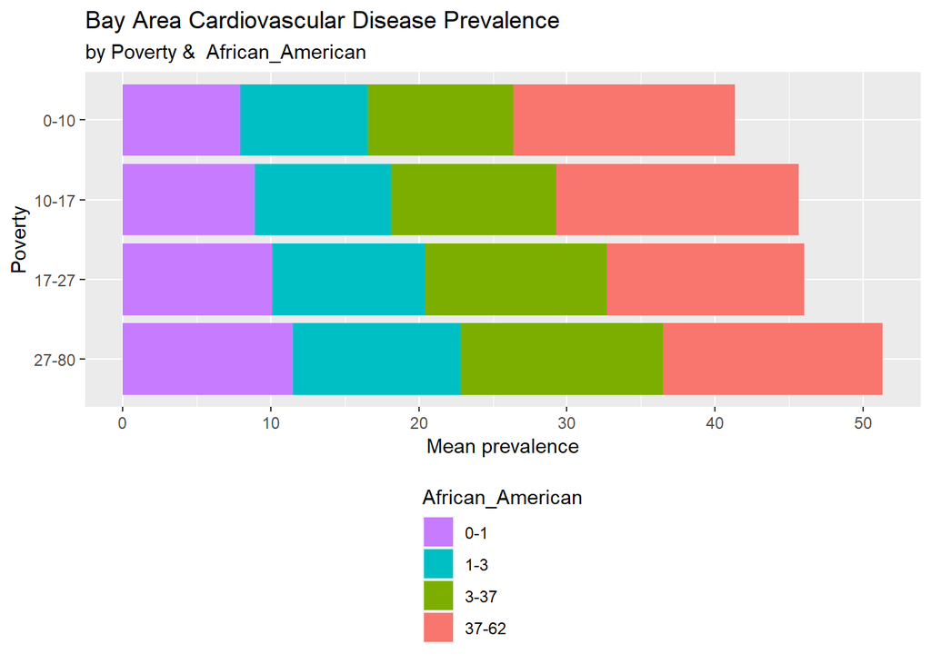

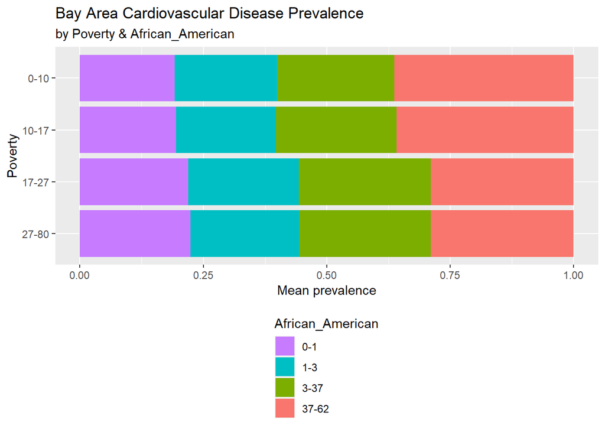

# ——————————————————————————

# (8)Check confounding – Mean Cardiovascular Disease Prevalence: African American by Unemployment rate

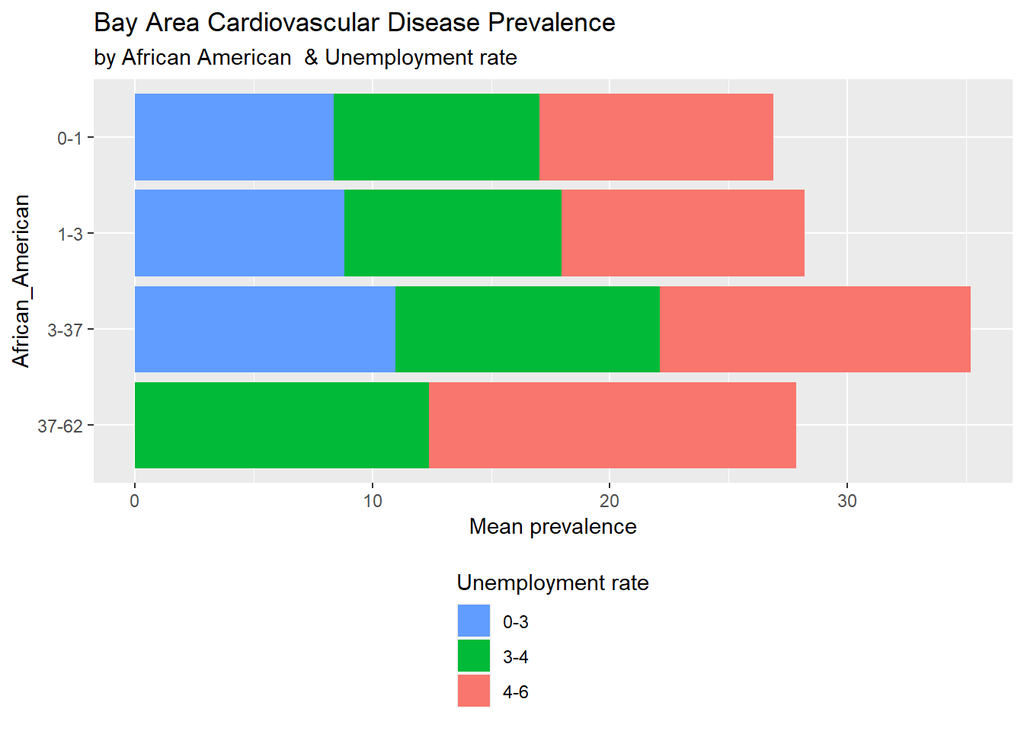

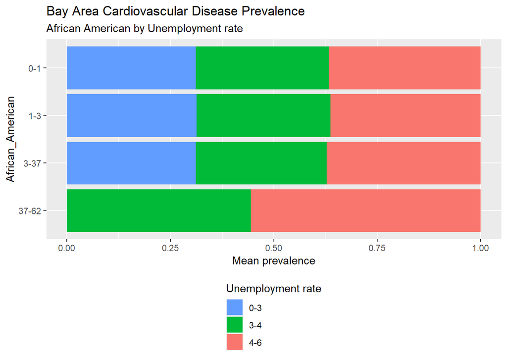

Result: As the Unemployment rate increases, the Mean Cardiovascular Disease Prevalence gets larger. As the African American percentage increases, the Mean Cardiovascular Disease Prevalence gets larger, too. For the groups with higher Unemployment rate, the Mean Cardiovascular Disease Prevalence increases as African American percentage increases.

# ——————————————————————————

# Question 4: Could the key risk factors predict the Cardiovascular Disease Prevalence?

# Use of Logistic regression to predict the Cardiovascular Disease Prevalence

# Factors: Hispanic, African American, Ozone

# Target Variable of the logistic regression: Cardiovascular Disease Prevalence

# Define the Cardiovascular Disease Prevalencethe to be a binary variable as follow:

# Cardiovascular Disease Prevalence > median (9.93) is coded to be

# – “1” , for “high” Cardiovascular Disease Prevalence area

# – “0”, (otherwise) for “low” Cardiovascular Disease Prevalence area

# ——————————–

# Estimate logit model using glm

# Y value is the log(Odds), predictors: Hispanic, African American, Ozone

```
##
## Call:
## glm(formula = cardio_flag ~ Hispanic + African_American + Ozone,
##     family = quasibinomial(), data = ces4_bay_all_Demographic_logit)
##
## Deviance Residuals:
##     Min       1Q   Median       3Q      Max
## -2.7231  -0.8113   0.1475   0.8667   2.1319
##
## Coefficients:
##                    Estimate Std. Error t value Pr(>|t|)
## (Intercept)       -6.587790   0.582108 -11.317   <2e-16 ***
## Hispanic           0.063452   0.004922  12.891   <2e-16 ***
## African_American   0.099000   0.010745   9.214   <2e-16 ***
## Ozone            130.988416  15.471123   8.467   <2e-16 ***
## ---
## Signif. codes:  0 '***' 0.001 '**' 0.01 '*' 0.05 '.' 0.1 ' ' 1
##
## (Dispersion parameter for quasibinomial family taken to be 1.043026)
##
##     Null deviance: 2093.2  on 1509  degrees of freedom
## Residual deviance: 1540.9  on 1506  degrees of freedom
## AIC: NA
##
## Number of Fisher Scoring iterations: 5
```

Result: Based on the summary of the estimated logit model, Hispanic, African American, Ozone are all significant with p value less than 0.001. The order for the significance of the factor effect is: Hispanic > African American > Ozone.

# ——————————————————————————

# Odds of Cardiovascular Disease Prevalence for each factor – taking exp() of each GLM coefficient to calculate the odds

```
##      (Intercept)         Hispanic African_American            Ozone
##     1.377079e-03     1.065508e+00     1.104066e+00     7.718734e+56
```

# ——————————————————————————

# Probability of Cardiovascular Disease Prevalence for each factor

```
##      (Intercept)         Hispanic African_American            Ozone
##      0.001375186      0.515857567      0.524729756      1.000000000
```

# ——————————————————————————

# Prediction of logistic regression

# ——————————————————————————

# 2*2 Table

# ——————————————————————————

```
##
## .      FALSE TRUE
##   No     590  159
##   Yes    226  535
```

The key factors derived from the Correlation analysis, Simple regression and Multiple regression are used as the predictors to forecast the high/low Cardiovascular Disease Prevalence census tracts. Other important factors which are not considered here may be included in the model to further improve the prediction accuracy of the model.